# act_report

## Analysis & Visualization Report

Three separate bits of analysis were carried out:

- Ratings by dog type (Floofer, Puppo, etc)
- Ratings by breed
- Ratings by Time

### Dog type analysis

#### Build a frame of dog type features, including the counts and mean ratings, likes and retweets, and generate plots

##### Owner ratings are similar, regardless of type

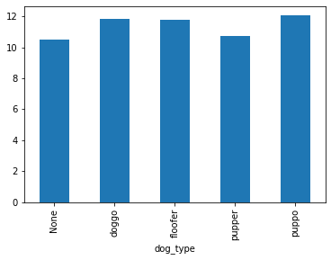

##### Puppos get most likes on average

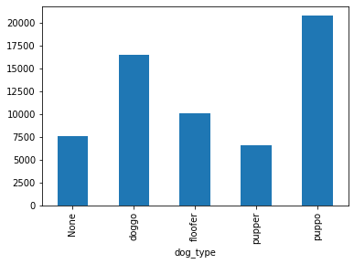

##### Puppos get most retweets on average

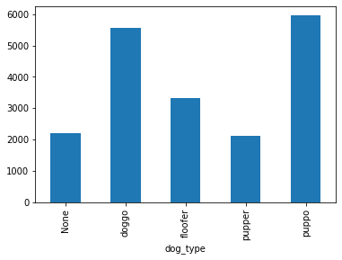

##### Looking at the ratios off likes to owner ratings, we see the same pattern

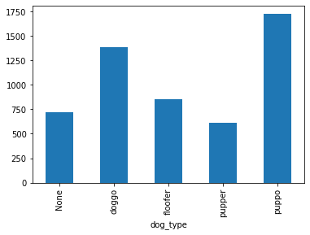

**Conclusion:** The community prefers Puppos

### Breed Analysis

#### Build a frame of breed features, including the counts and mean ratings, likes and retweets, and generate plots

##### Owner ratings are similar, regardless of breed

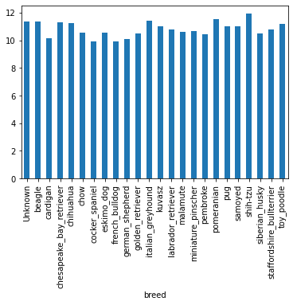

##### Shih-tzus get significantly more likes

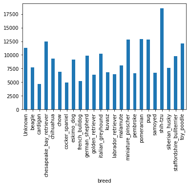

##### Shih-tzus get significantly more retweets

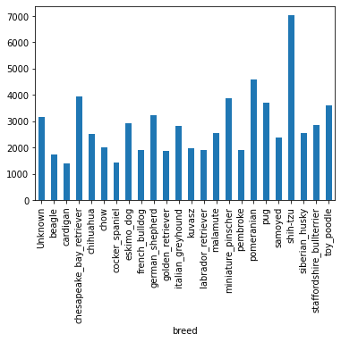

##### Looking at the ratios of likes to owner ratings, we see the same pattern

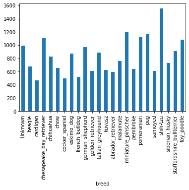

**Conclusion:** The community really likes Shih-tzus, and shows a marked preference for smaller breeds generally. Combined with the preference for Puppos found above, **this suggests that small dogs are cute.** Who knew?

### Is there a relationship between rating and timestamp?

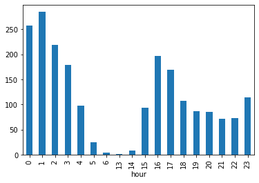

Looking at the tweet frequency by hour of the day there is an obvious dip between 5 and 14 - presumably this is night-time - which makes sense if we assime that tweet times are in UTC and the user base is mainly in the USA)

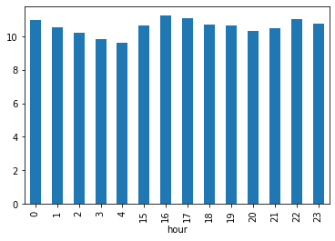

**Conclusion:** Assuming that the period 5- 14 is when folk are asleep it is apparent that owners like their dogs early in the morning and less and less the later it gets at night.